# What Determines Women’s Employment in Urban Slums?

Role of Marital Status, Family Structure, and Age

Ramesh Beniwal

2026-11-03

## Introduction

### Motivation

- Women’s employment is a key indicator of **empowerment** and household welfare
- Urban slum women face multiple barriers — family structure, marital status, and social norms
- Very few studies focus on determinants of employment among slum women in India
- This study uses data from **four urban slums** — Atal Ayub Nagar, Nawab Colony, J.P Nagar, Arif Nagar

### Research Question

*“What determines women’s employment in urban slums — role of marital status, family structure, and age?”*

- **Dependent:** Currently Working (Yes/No)
- **Independent:** Marital Status, Family Type, Age
- **Controls:** Education, In-laws Alive

## Data Cleaning

- Data collected from **four urban slums** in 2026
- Age = 0 replaced with **NA** — data entry error
- Education > 16 replaced with **NA** — beyond questionnaire range
- Marital status recoded: **Widowed / Separated = 1**, others = 0
- Education grouped into six categories: **Illiterate, Primary, Middle, Secondary, Higher Secondary, Graduate & Above**
- Age grouped into six categories: **18–24, 25–34, 35–44, 45–54, 55–64, 65+**
- **Binary dummies** created for each education and age category

## Summary Statistics (Slums)

| Variable | N | Mean | Std. Dev. | Min | Max |
| --- | --- | --- | --- | --- | --- |
| Panel A: Dependent Variable |  |  |  |  |  |
| Currently Working (Yes = 1) | 639 | 0.178 | 0.383 | 0 | 1 |
| Panel B: Independent Variables |  |  |  |  |  |
| Marital Status |  |  |  |  |  |
| Married (Yes = 1) | 642 | 0.863 | 0.344 | 0 | 1 |
| Unmarried (Yes = 1) | 642 | 0.006 | 0.079 | 0 | 1 |
| Widowed / Separated (Yes = 1) | 643 | 0.131 | 0.337 | 0 | 1 |
| Family Structure |  |  |  |  |  |
| Joint Family (Yes = 1) | 642 | 0.340 | 0.474 | 0 | 1 |
| Age Groups |  |  |  |  |  |
| Age 18–24 | 641 | 0.061 | 0.239 | 0 | 1 |
| Age 25–34 | 641 | 0.298 | 0.458 | 0 | 1 |
| Age 35–44 (ref) | 641 | 0.293 | 0.456 | 0 | 1 |
| Age 45–54 | 641 | 0.192 | 0.394 | 0 | 1 |
| Age 55–64 | 641 | 0.120 | 0.325 | 0 | 1 |
| Age 65+ | 641 | 0.036 | 0.186 | 0 | 1 |
| Panel C: Control Variables |  |  |  |  |  |
| Education Categories |  |  |  |  |  |
| Illiterate — No Schooling (ref) | 627 | 0.327 | 0.469 | 0 | 1 |
| Primary — 1 to 5 years | 627 | 0.144 | 0.351 | 0 | 1 |
| Middle — 6 to 8 years | 627 | 0.215 | 0.411 | 0 | 1 |
| Secondary — 9 to 10 years | 627 | 0.187 | 0.390 | 0 | 1 |
| Higher Secondary — 11 to 12 years | 627 | 0.078 | 0.269 | 0 | 1 |
| Graduate and Above — 13 to 16 years | 627 | 0.049 | 0.217 | 0 | 1 |
| In-laws |  |  |  |  |  |
| Father-in-law Alive (Yes = 1) | 640 | 0.291 | 0.454 | 0 | 1 |
| Mother-in-law Alive (Yes = 1) | 639 | 0.469 | 0.499 | 0 | 1 |

## Employment by Marital Status

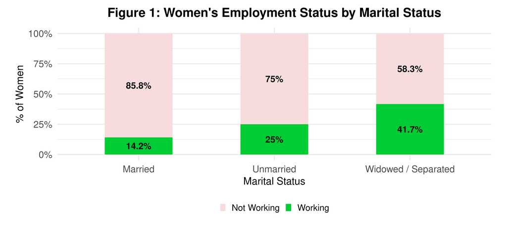

Figure 1: Women’s Employment Status by Marital Status

## Employment by Family Structure

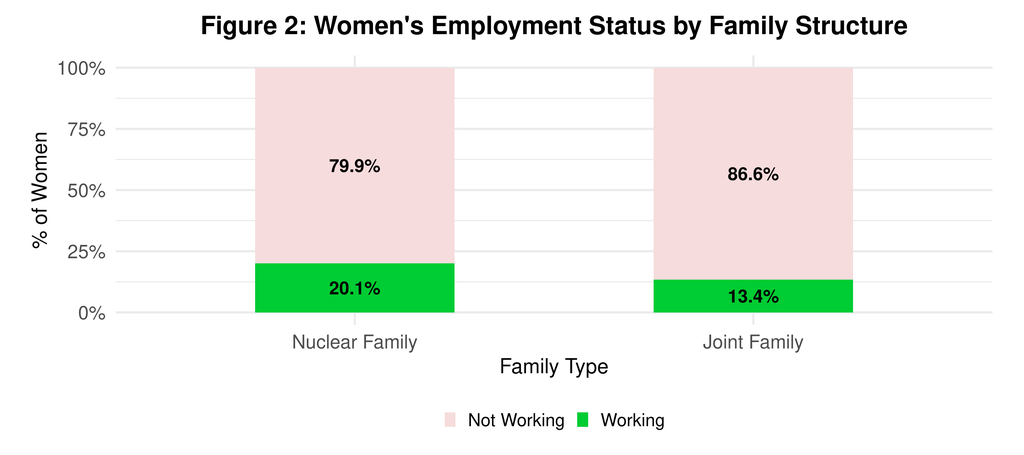

Figure 2: Women’s Employment Status by Family Structure

## Employment by Age Group

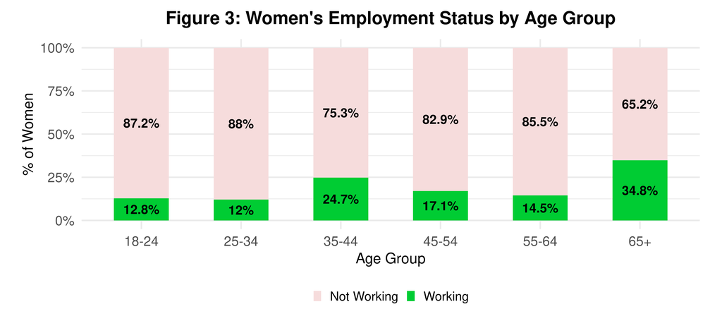

Figure 3: Women’s Employment Status by Age Group

## Employment by Education Level

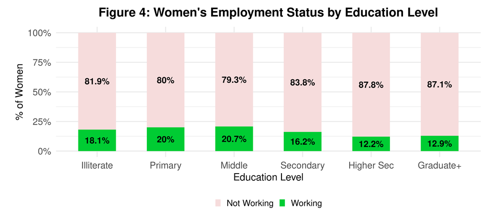

Figure 4: Women’s Employment Status by Education Level

## Key Findings

**📊 Marital Status**

- Married → **14.2%** working
- Unmarried → **25.0%** working
- Widowed / Separated → **41.7%** working
- Economic necessity drives work after loss of spouse

**🏠 Family Structure**

- Nuclear family → **20.1%** working
- Joint family → **13.4%** working
- Joint families **restrict** women’s mobility and work decisions

## Thank You

**Ramesh Beniwal**

*Women’s Employment Study | Urban Slums | 2026*